# Snowshoe Hares - Exploratory Report

Kirsten White

November 9, 2021

# **Introduction**

This report provides an exploratory overview of juvenile snowshoe hare populations observed in the Bonanza Creek Experimental Forest in Alaskan boreal forests from 1998 to 2012 (Kielland, K, et al 2017). Data was collected on showshoe hares (Lepus americanus) by Knut Kielland and colleagues in Bonanza Creek Experimental Forest, part of the US Long Term Ecological Research Network (LTER). Capture-recapture of snowshoe hares was conducted at 5 locations in the Tanana Valley in an effort to evaluate population fluctuations within the keystone prey species. In this report, total juvenile trap counts are evaluated by year and particular characteristics are evaluated. More specifically, male and female weight is compared and the relationship between hare weight and hind foot length is explored.

# **Data & Analysis**

The data in this report contains observations for 371 juvenile hares gathered between 1998 and 2012. Following exploratory data visualization, juvenile male and female hare weights are evaluated with a two-sample t-test using a significance level of 0.05 throughout. Differences are explored using Cohen’s d effect size nd the relationship between weight and hindfoot length is investigated using simple linear regression. All analyses are in R Version 4.1.1 using R studio version 1.4.1717.

**Data Citation**: Kielland, K., F.S. Chapin, R.W. Ruess, and Bonanza Creek LTER. 2017. Snowshoe hare physical data in Bonanza Creek Experimental Forest: 1999-Present ver 22. Environmental Data Initiative. https://doi.org/10.6073/pasta/03dce4856d79b91557d8e6ce2cbcdc14

# **Results**

## **Part 1: Juvenile Hare Trapping Counts**

Total number of juvenile snowshoe hares trapped during each year of the study (1998 - 2012) are visualized in a bar graph and a summary stastitics table.

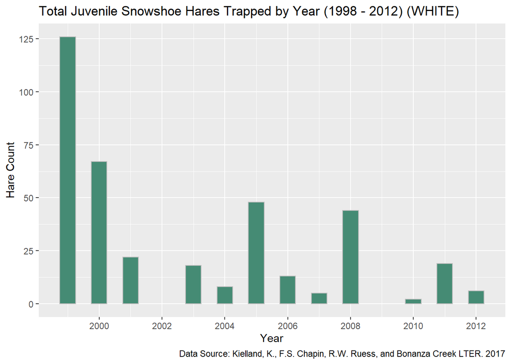

**Figure 1**: Total number of juvenile hares trapped per year from 1998 through 2012. No counts were collected in 2002 and 2009.

**Table 1**: Summary statistics for juvenile hare counts from 1998 - 2012

| Age | Sample Size | Min | Max | Mean | Median | Standard Deviation |
| --- | --- | --- | --- | --- | --- | --- |
| j | 12 | 2 | 126 | 31.5 | 18.5 | 35.9 |

## **Part 2: Juvenile Hare Weights**

Juvenile snowshoe hare weights are compared by sex and site and visualized in a scatterplot.

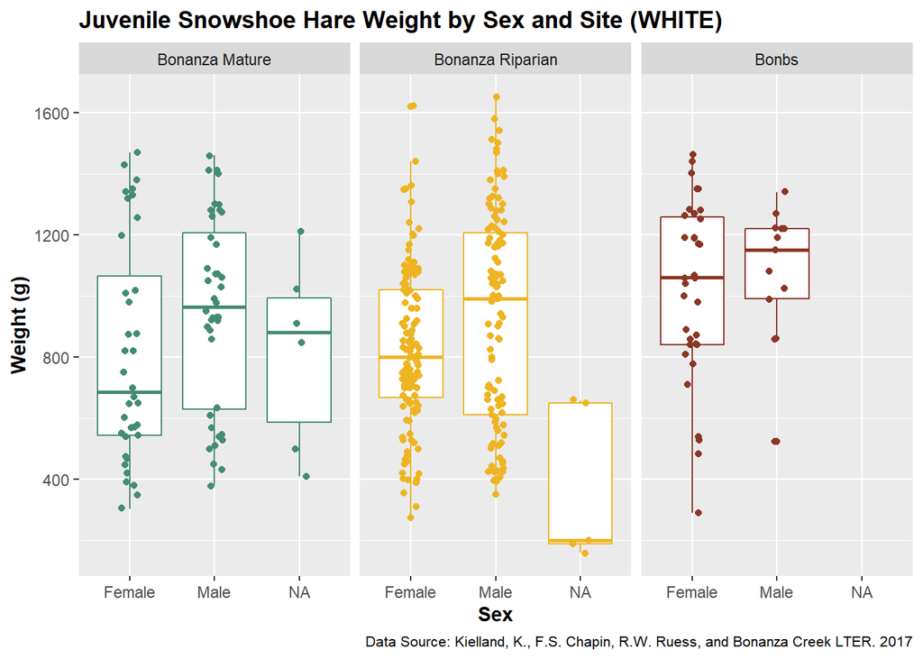

**Figure 2**: Female and male juvenile hare weights are visualized by sex (female, male, and NA) and site, including: Mature (green), Riparian (gold), and Bonbs (maroon). Each point represents an individual observation for a juvenile hare weight. Box plots indicate the median, range, and outliers for each group.

**Table 2**: Summary statistics for male and female juvenile weights (g) separated by site

| Site | Sex | Sample Size | Mean (g) | Median (g) | Min (g) | Max (g) | Standard Deviation (g) |
| --- | --- | --- | --- | --- | --- | --- | --- |
| Bonanza Mature | Female | 36 | 808.2 | 685 | 305 | 1470 | 361.1 |
| Bonanza Mature | Male | 40 | 950.1 | 965 | 380 | 1460 | 314.7 |
| Bonanza Mature | NA | 6 | 816.7 | 880 | 410 | 1210 | 307.1 |
| Bonanza Riparian | Female | 127 | 824.1 | 800 | 275 | 1620 | 255.0 |
| Bonanza Riparian | Male | 110 | 929.3 | 990 | 350 | 1650 | 349.2 |
| Bonanza Riparian | NA | 5 | 372.0 | 200 | 160 | 660 | 258.8 |
| Bonbs | Female | 34 | 1022.1 | 1060 | 290 | 1460 | 293.0 |
| Bonbs | Male | 13 | 1073.1 | 1150 | 525 | 1340 | 222.6 |

**Analysis**: While hare weights recorded at the Bonbs site appear to have higher weights (both in mean and median), it is important to note the large disparity in sample sizes is evident between each site. Counts from the Bonanza Riparian site had a significantly higher sample size (242 hares) compared to the other two sites (82 and 47 hares). Additionally, spread in weight value is high between each site and both sexes.

## **Part 3: Juvenile Weight Comparison**

| Sex | Sample Size | Mean (g) | Median (g) | Min (g) | Max (g) | Standard Deviation (g) |
| --- | --- | --- | --- | --- | --- | --- |
| Female | 197 | 855.4 | 825 | 275 | 1620 | 292.3 |
| Male | 163 | 945.9 | 990 | 350 | 1650 | 333.2 |
| NA | 11 | 614.5 | 650 | 160 | 1210 | 357.6 |

**Analysis**: On average, male juvenile hares weigh more than female juvenile hares. The actual difference in mean weight is 90.5 (g) and the percent difference is 10%. In addition, the difference in means was found to be statistically significant (Welch’s two-sample t-test: t(325) = -2.7, p < 0.05) with a small effect size (Cohen’s d = -0.29). Therefore, further investigation is needed to identify whether male snowshoe hares have an actual significant difference in weight compared to female snowshoe hares.

## **Part 4: Juvenile Hare Weight & Hind Foot Length**

The relationship between juvenile snowshoe hare hind foot length and weight is explored, visualized, and analyzed.

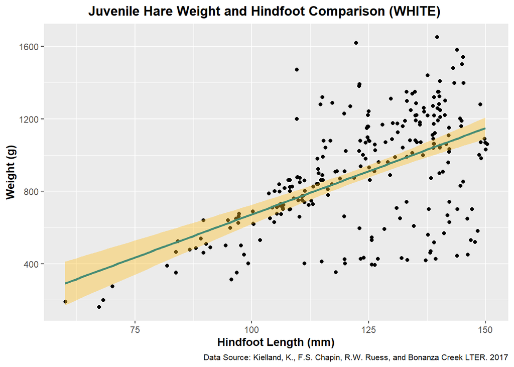

**Figure 3**: A simple linear regression was used to explore the relationship between hind foot length (mm) and body weight (g) across all juvenile snowshoe hares (male and female).

**Linear Model Analysis**: Based on this initial impression, the relationship appears heteroscedastic since the spread of residuals about the model changes in a non-random way (more outliers) as hind foot length increases and weight becomes less predictable.

# **Summary**

Exploratory data analysis reveals the following:

# **Citations**

1. Data citation: Kielland, K., F.S. Chapin, R.W. Ruess, and Bonanza Creek LTER. 2017. Snowshoe hare physical data in Bonanza Creek Experimental Forest: 1999-Present ver 22. Environmental Data Initiative. https://doi.org/10.6073/pasta/03dce4856d79b91557d8e6ce2cbcdc14